# Praca domowa 2

Imię Nazwisko - Maciej Adamczuk

## Dane

Dane wykorzystane w Pracy domowej 2 są związane z kampaniami marketingu bezpośredniego portugalskiej instytucji bankowej. Kampanie marketingowe opierały się na rozmowach telefonicznych. Często wymagany był więcej niż jeden kontakt z tym samym klientem, aby uzyskać dostęp do tego, czy produkt (lokata bankowa) zostanie (lub nie) subskrybowany. Opis wszystkich kolumn znajduje się również w pliku `README.md`.

#### Dane klienta banku

| Zmienna | Opis |
| --- | --- |
| **age** | wiek |
| **job** : admin., unknown, unemployed, management, housemaid, entrepreneur, student, blue-collar, self-employed, retired, technician, services | administrator, nieznany, bezrobotny, kierownictwo, pokojówka, przedsiębiorca, student, pracownik fizyczny, samozatrudniony, emeryt, technik, usługi |
| **marital** : married, divorced, single; note: divorced means divorced or widowed) | żonaty/zamężna, rozwiedzion_, kawaler/panna; uwaga: rozwiedzion_ oznacza rozwiedzion_ lub owdowiał_ |
| **education** : unknown, secondary, primary, tertiary | nieznane, średnie, podstawowe, wyższe |
| **default** : yes, no | czy kredyt jest niespłacany : tak, nie |
| **balance** : average yearly balance, in euros | średnie roczne saldo w euro |
| **housing** : has housing loan? yes, no | czy posiada kredyt mieszkaniowy? tak, nie |
| **loan** : has personal loan? yes, no | ma pożyczkę osobistą? tak, nie |

#### Dane związane z ostatnim kontaktem w bieżącej kampanii

| Zmienna | Opis |
| --- | --- |
| **contact** : unknown, telephone, cellular | nieznany, telefon, komórkowy |
| **day** : last contact day of the month | dzień miesiąca ostatniego kontaktu |
| **month** : last contact month of year, jan, feb, mar, …, nov, dec | miesiąc ostatniego kontaktu w roku, styczeń, luty, marzec, …, listopad, grudzień |
| **duration** : last contact duration, in seconds | czas trwania ostatniego kontaktu w sekundach |

## Zadanie 1

Weźmy pod uwagę zawody (`job`) klientów banku. Który zawód zacząco wyróżnia się w posiadaniu kredytu mieszkaniowego lub pożyczki osobistej?

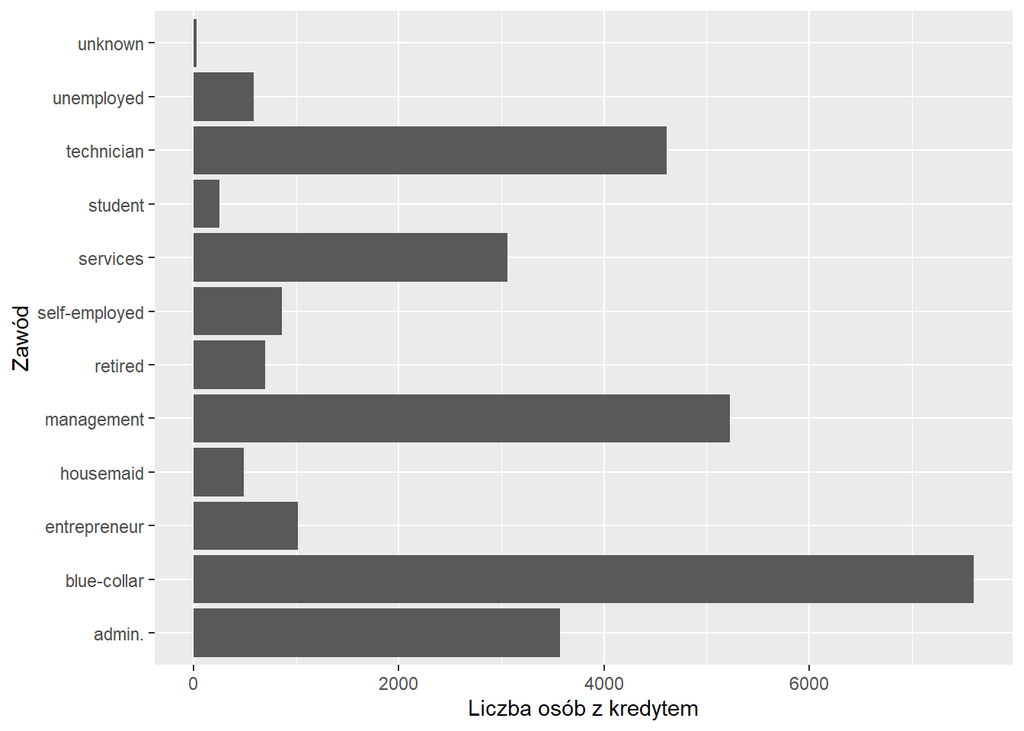

```r
df %>%
  filter(housing == "yes" | loan == "yes") %>%
  ggplot(aes(y=job))+
  geom_bar() +
  labs(y = "Zawód", x = "Liczba osób z kredytem")
```

**Komentarz:**

Pod względem liczności osób z kredytem mieszkanowym lub pożyczką wyrózniają się tzw. niebieskie kołnierzyki, czyli pracownicy fizyczni, produkcyjni lub administracyjni niższego szczebla.

## Zadanie 2

Wybierając klientów, którzy mają nieznany sposób kontaktu (`contact`). Jak rozkłada się ich wiek w podziale na status związku?

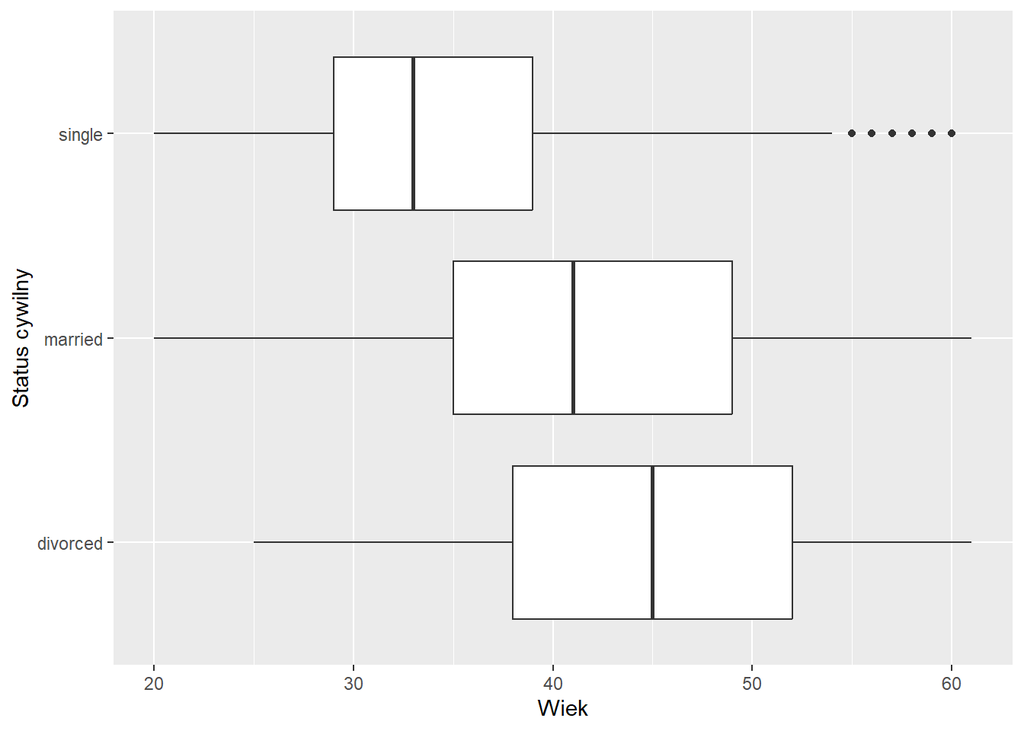

```r
df %>%
  filter(contact == "unknown") %>%
  ggplot(aes(y=marital,x = age)) +
  geom_boxplot() +
  labs(x = "Wiek", y="Status cywilny")
```

**Komentarz:**

Prawie wszyscy klienci, dla których sposób kontaktu są nieznani i są singlami, mieszczą się w przedziale 20-54 lata, powyżej jest jedynie kilku outlierów. W większości są to osoby w wieku 29-39 lat i średnią wieku 33 lata. Żonaci znajdują się na całym przedziale wiekowym (20-61) , ale najbardziej skoncentrowani są na przedziale 35-49, ze średnią 41. Rozwodników można znaleźć na przedziale 25-61 ze średnią 45. Najbardziej skoncentrowani są na przedziale 38-52.

## Zadanie 3

Jaka jest różnica pomiędzy średnim rocznym saldem w euro w zależności od wykształcenia i tego czy kredyt jest niespłacany?

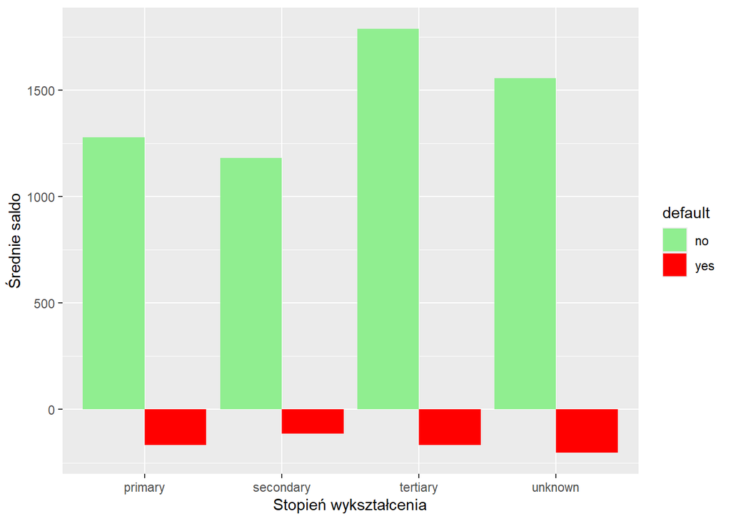

```r
df %>%
  group_by(education, default) %>%
  summarise(mean_balance = mean(balance)) %>%
  ggplot(aes(x=education, y = mean_balance, fill=default)) +
  geom_col(position = "dodge") +
  scale_fill_manual(values = c("lightgreen","red")) +
  labs(y = "Średnie saldo", x="Stopień wykształcenia")
```

**Komentarz:**

Dla każdego poziomu wykształcenia różnica w średnim rocznym saldzie pomiędzy osobami spłacającymi kredyt, a tymi którzy go nie spłacają wynosi co najmniej ok. 1300 euro. Największa różnica jest w przypadku osób z wykształceniem wyższym, gdzie osoby spłacające kredyt średnio uzyskają saldo wyższe o ok. 1900 euro, względem osób, które kredytu nie spłacają. Podobna różnica jest najmniejsza w przypadku osób o wykształceniu średnim, gdzie wynosi ok. 1300 euro. Dla osób z wykształceniem podstawowym jest to ok. 1400 euro, natomiast dla osób z nieznanym wykształceniem ok. 1700 euro.

## Zadanie 4

Czy dzień i miesiąc kontaktu z klientem ma wpływ na średni czas trwania rozmowy w stosunku do średniego czasu trwania rozmowy?

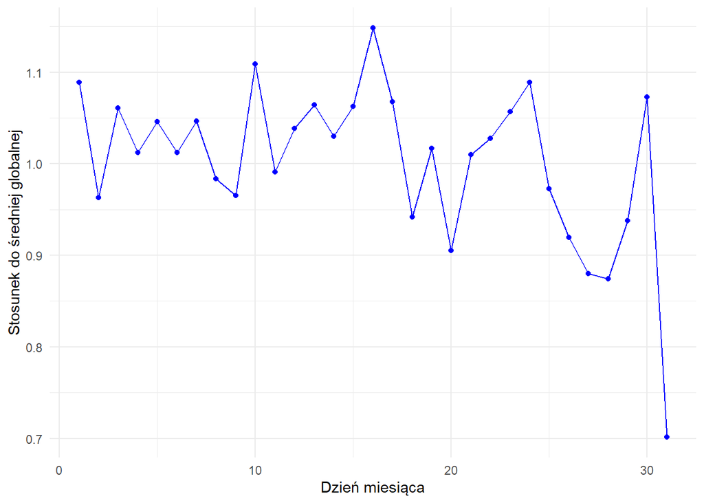

```r
df %>%
  group_by(day) %>%
  summarise(mean_duration = mean(duration)) %>%
  mutate(mean = mean_duration / mean(df$duration)) %>%
  ggplot(aes(x = day, y = mean)) +
  geom_point(color = "blue") +
  geom_path(aes(y = mean), color = "blue") +
  theme_minimal() +
  labs(y = "Stosunek do średniej globalnej", x = "Dzień miesiąca")
```

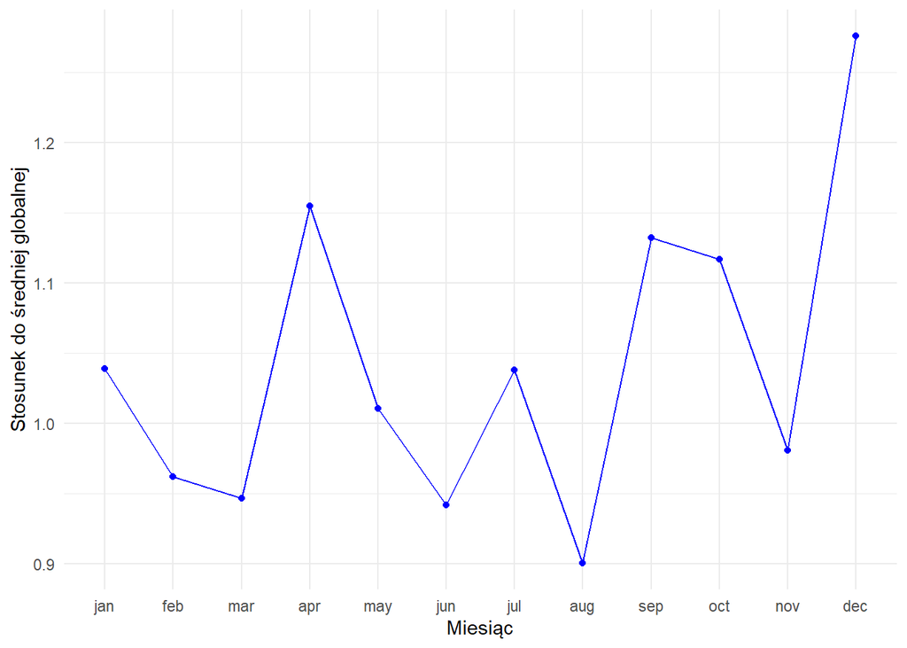

```r
months_order <- c("jan", "feb", "mar", "apr", "may", "jun", "jul", "aug", "sep", "oct", "nov", "dec")

df %>%
  group_by(month) %>%
  summarise(mean_duration = mean(duration)) %>%
  mutate(mean = mean_duration / mean(df$duration), month = factor(month, levels=months_order)) %>%
  arrange(month) %>%
  ggplot(aes(x = month, y = mean)) +
  geom_point(color = "blue") +
  geom_path(aes(y = mean), color = "blue", group=1) +
  theme_minimal() +
  labs(y = "Stosunek do średniej globalnej", x = "Miesiąc")
```

**Komentarz:**

Z wykresów można zauważyć, że rozmowy odbywające się w pierwszej połowie miesiąca trwają zazwyczaj dłużej, niż te odbywające się w drugiej połowie, natomiast jeśli chodzi o miesiące to najdłużej trwają rozmowy prowadzone w grudniu, a najkrócej w lutym, marcu, czerwcu i sierpniu.

## Zadanie 5

Czy jest zależnośc pomiędzy wiekiem klientów a ich średnim rocznym saldzie w euro w podziale na stopień wykształcenia?

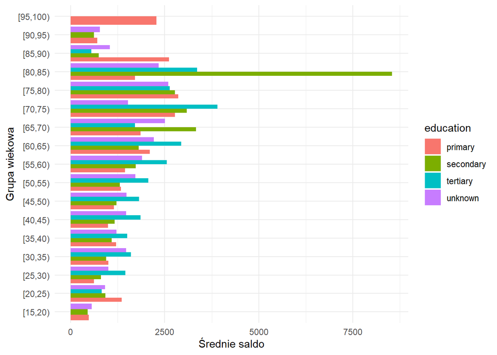

```r
df %>%
  mutate(grupa_wiekowa = cut(age, breaks = seq(10, 100, by = 5), right = FALSE)) %>%
  group_by(grupa_wiekowa, education) %>%
  summarise(mean_balance = mean(balance)) %>%
  ggplot(aes(y=grupa_wiekowa, x=mean_balance, fill=education)) +
  geom_col(position="dodge") +
  theme_minimal() +
  labs(y = "Grupa wiekowa", x = "Średnie saldo")
```

**Komentarz:**

Poczynając od grup wiekowych, gdzie większość osób uzyskała już wykształcenie wyższe (25+) zaczyna ono przeważać pod względem średniego rocznego salda, aż do momentu dojścia do osób starszych (65+). W przedziale 25-65 zazwyczaj saldo osób z wykształceniem średnim i podstawowym jest bardzo podobne, natomiast u osób, gdzie wykształcenie jest nieznane zazwyczaj plasuje się ono jedynie za wykształceniem wyższym. Dla osób starszych natomiast nie widzę prawidłowości, może to wynikać z mniejszej próbki dla osób starszych, lub np. z tego że niektórzy już nie pracują i jedynie pobierają emeryture.

## Zadanie 6

Rozważmy osoby, które są bezrobotne albo ich zawód jest nieznany. Czy procent osób, które są bezrobotne i nie spłacają kredytu jest większy od procenta osób o nieznanym zawodzie i nie spłacanym kredycie? Jaki typ kredytu jest (przez te osoby) najczęściej niespłacany?

```r
total_unknown <- df %>%
  filter(job == "unknown") %>%
  nrow()

total_unemployed <- df %>%
  filter(job == "unemployed") %>%
  nrow()

df %>%
  filter(job == "unemployed" & default == "yes" | job == "unknown" & default == "yes") %>%
  group_by(job) %>%
  summarise(default_percentage = n()) %>%
  mutate(default_percentage = case_when(job == "unemployed" ~ default_percentage*100/total_unemployed,
                                        job == "unknown" ~ default_percentage*100/total_unknown))
```

```
## # A tibble: 2 × 2
##   job        default_percentage
##   <chr>                   <dbl>
## 1 unemployed              2.30
## 2 unknown                 0.694
```

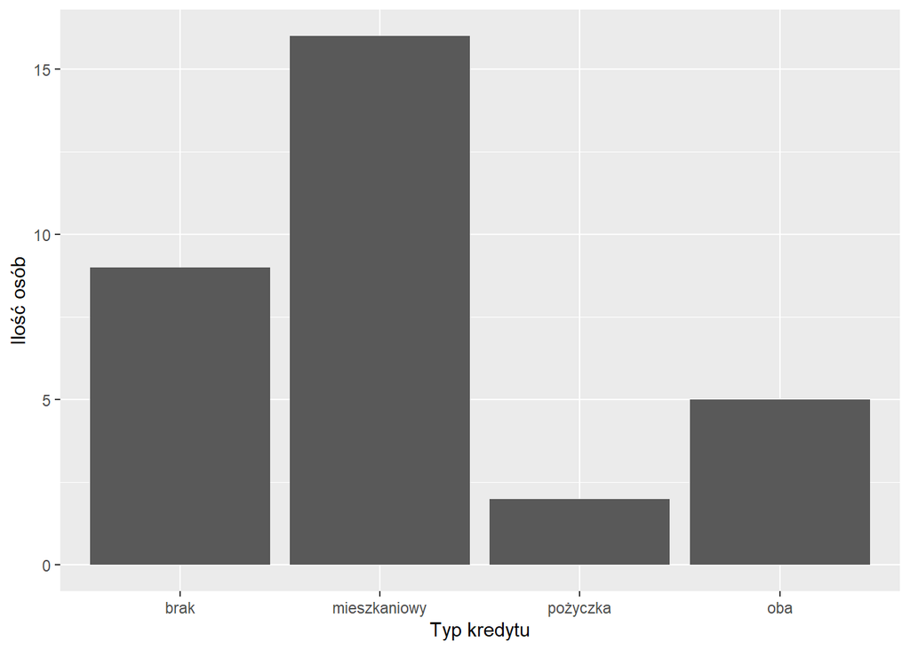

```r
credit_order <- c("brak", "mieszkaniowy", "pożyczka", "oba")
df %>%
  filter(job == "unemployed" & default == "yes" | job == "unknown" & default == "yes") %>%
  group_by(default, housing, loan) %>%
  summarise(count = n()) %>%
  mutate(credit = case_when(housing == "no" & loan=="no" ~ "brak",
                            housing == "yes" & loan=="no" ~ "mieszkaniowy",
                            housing =="no" & loan=="yes" ~ "pożyczka",
                            TRUE ~ "oba"),
         credit = factor(credit, levels=credit_order)) %>%
  arrange(credit) %>%
  ggplot(aes(x=credit, y = count)) +
  geom_col() +
  labs(y = "Ilość osób", x = "Typ kredytu")
```

**Komentarz:**

Procent osób, które są bezrobotne i nie spłacają kredytu jest ok. 3 razy większy od procenta osób, których zawód jest nieznany i nie spłacają kredytu. Wśród osób bezrobotnych i o nieznanym zawodzie najczęściej niespłacany jest kredyt mieszkaniowy.